# S3

This electronic supplementary material aims to document in a reproducible manner the simulation results presented in the main text regarding the **vaccination** structure.

# 1 Vaccination sub-model

## 1.1 Equations

$$\begin{equation} \label{eq:4}
\begin{aligned}
\dot{S_t} &= -\lambda_t S_t - \psi_t S_t\\
\dot{S^h_t} &= -\lambda_t S^h_t \\
\dot{S^v_t} &= (1 - \phi)\psi_t S_t -\lambda_t S^v_t\\
\dot{E_t} &= \lambda_t (S_t + S^v_t) - \sigma E_t\\
\dot{R_t} &= \gamma I_t + \kappa A_t + \phi \psi_t S_t
\end{aligned}
\end{equation}$$

As with the *TTI* structure, we model vaccination capacity using the logistic growth structure. Furthermore, considering that vaccines are not available at the start of the pandemic, we introduce an if-else function to account for this feature.

$$\begin{equation} \label{eq:5}
\begin{aligned}
\psi_t &= \frac{\min(S_t, f(Q^v_t, \tau^v))}{S_t} \\
f(Q_t, \tau) &= \begin{cases}
0, & \text{for } t < \tau \\
\frac{Q_t N}{1000}, & \text{for } t \geq \tau
\end{cases}\\
\dot{Q^v_t} &= \begin{cases}
0, & \text{for } t < \tau \\
\rho^v Q^v_t (1 - \frac{Q^v_t} {\alpha^v}), & \text{for } t
\geq \tau
\end{cases}\\
\end{aligned}
\end{equation}$$

## 1.2 Partial calibration

To configure the logistic structure in the vaccination sub-model, we use data from the COVID-19 in the Netherlands and model calibration. This data indicates that vaccination’s initial capacity in Feb 2021 was 230.000 per week. From April onwards, it was between 400.000-500.000 per week, and 6 weeks were needed to scale up to 1.500.000 per week[^1].

```r
data_vacc <- data.frame(time  = c(0, 60, 102),
                        value = 1000 * (c(230000, 400000, 1500000) / 7) / pop_val)

est_obj <- estimate_rho(data_vacc)

par_rho_v   <- est_obj$estimate
Qv_0        <- data_vacc$value |> head(1)
par_alpha_v <- data_vacc$value |> tail(1)
```

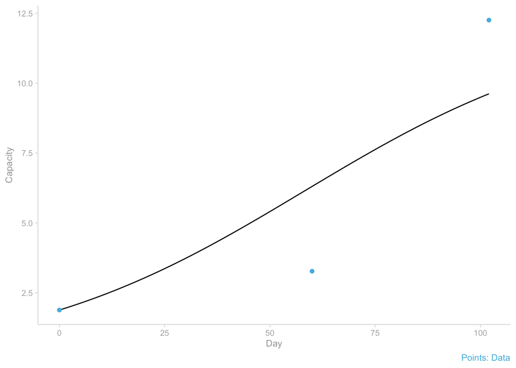

```r
plot_fit(est_obj$sim, data_vacc)
```

# 2 Comprehensive intervention (TTI + MR + V)

All interventions are integrated into a single model (3B_TTI_PLUS_MR_PLUS_V.stmx).

## 2.1 Validation

Before exploring the impact of a comprehensive approach, we verify that the integrated model and intervention-specific models produce identical output under equivalent configurations.

```r
fp_synthesis <- "./models/3B_TTI_PLUS_MR_PLUS_V.stmx"

mdl_sth <- read_xmile(fp_synthesis,
                     const_list = c(bio_params,
                                    par_zeta_0 = zeta_val,
                                    par_rho_v   = par_rho_v,
                                    par_alpha_v = par_alpha_v,
                                    par_phi     = phi_val,
                                    par_iota_v  = iota_v_val,
                                    par_iota_d  = iota_d_val,
                                    par_delta   = delta_val,
                                    par_rho_d   = test_cap_pars$rho_d,
                                    par_alpha_d = test_cap_pars$alpha_d,
                                    par_rho_k   = ct_cap_pars$rho_k,
                                    par_alpha_k = ct_cap_pars$alpha_k,
                                    par_tau_m   = par_tau_m,
                                    par_tau_v   = tau_v_val,
                                    par_xi      = 0.8),
                      stock_list = list(Qv = Qv_0,
                                        Qd = test_cap_pars$Qd,
                                        Qk = ct_cap_pars$Qk,
                                        Qm = Qm_0))
```

```r
par_tau_v_test <- 0

# Scenarios data frame
# First scenario: No intervention
# Second scenario: Testing and Isolation (TI)
# Third scenario: Contact tracing (CT)
# Fourth scenario: Mobility restrictions (MR)
# Fifth scenario: Vaccination (V)
s_df <- data.frame(Qd         = c(0, Qd_0, Qd_0, 0, 0),
                   Qk         = c(0, 0, Qk_0, 0, 0),
                   Qm         = c(0, 0, 0, Qm_0, 0),
                   Qv         = c(0, 0, 0, 0, Qv_0),
                   iter       = 1:5,
                   itv        = c("Base case", "TI", "CT", "MR", "V"),
                   par_tau_v  = par_tau_v_test)

sim_output_syn <- sd_sensitivity_run(mdl_sth$deSolve_components,
                                     stocks_df  = s_df |> select(-iter, - itv),
                                     consts_df  = s_df |> select(par_tau_v),
                                     start_time         = 0,
                                     stop_time          = 1000,
                                     timestep           = 1 / 32,
                                     reporting_interval = 1/ 8,
                                     multicore = TRUE, n_cores = 5) |>
  select(time, iter, C_in, Qv, Qd, Qk, Qm) |>
  mutate(model        = "Synthesis") |>
  left_join(s_df[, c("iter", "itv")])
```

```r
mdl_base <- read_xmile("./models/1A_SEI3R.stmx",
                  const_list = c(bio_params,
                                 par_beta = beta_vals[[2]]))
temp <- sd_simulate(mdl_base$deSolve_components,
                          start_time = 0,
                          stop_time = 1000,
                          timestep = 1 / 32)

sim_output_b <- temp |>   select(time, C_in) |>
  mutate(itv   = "Base case",
         model = "Single intervention")
```

```r
mdl_test <- read_xmile("./models/2B_TI_Logistic.stmx",
                       stock_list = list(Qd = Qd_0),
                       const_list = c(bio_params,
                                      par_beta    = beta_vals[[2]],
                                      par_alpha_d = test_cap_pars$alpha_d,
                                      par_rho_d   = test_cap_pars$rho_d,
                                      par_iota_d  = iota_d_val,
                                      par_delta   = delta_val))

sim_output_TI <- sd_simulate(mdl_test$deSolve_components,
                          start_time = 0,
                          stop_time = 1000,
                          timestep = 1 / 32) |>
  select(time, C_in) |>
  mutate(itv   = "TI",
         model = "Single intervention")
```

```r
fp_ct <- "./models/2C_TTI_Logistic.stmx"

mdl_ct       <- read_xmile(fp_ct, stock_list = list(Qd = test_cap_pars$Qd,
                                                 Qk = ct_cap_pars$Qk),
                        const_list = c(bio_params,
                                       par_zeta    = beta_vals[[2]] * 10,
                                       par_alpha_d = test_cap_pars$alpha_d,
                                       par_alpha_k = ct_cap_pars$alpha_k,
                                       par_rho_d   = test_cap_pars$rho_d,
                                       par_rho_k   = ct_cap_pars$rho_k,
                                       par_iota_d  = iota_d_val,
                                       par_delta   = delta_val))

sim_output_CT <- sd_simulate(mdl_ct$deSolve_components,
                          start_time = 0,
                          stop_time = 1000,
                          timestep = 1 / 32) |>
  select(time, C_in) |>
  mutate(itv   = "CT",
         model = "Single intervention")
```

```r
fp_mob <- "./models/3C_MR.stmx"

mdl_mob <- read_xmile(fp_mob,
                      const_list = c(bio_params,
                                     par_zeta_0 = beta_vals[[2]] * 10,
                                     par_tau_m = 0),
                      stock_list = list(Qm = Qm_0))

sim_output_MR <- sd_simulate(mdl_mob$deSolve_components,
                          start_time = 0,
                          stop_time = 1000,
                          timestep = 1 / 32) |>
  select(time, C_in) |>
  mutate(itv = "MR",
         model        = "Single intervention")
```

```r
v_fp <- "./models/3A_V.stmx"
mdl_v <- read_xmile(v_fp,
                    const_list = c(bio_params,
                                   par_beta = beta_vals[[2]],
                                   par_rho_v   = par_rho_v,
                                   par_alpha_v = par_alpha_v,
                                   par_phi     = phi_val,
                                   par_iota    = iota_v_val,
                                   par_tau_v   = par_tau_v_test),
                    stock_list = list(Qv = Qv_0))

sim_output_v <- sd_simulate(mdl_v$deSolve_components,
                          start_time = 0,
                          stop_time = 1000,
                          timestep = 1 / 32) |>
  select(time, C_in) |>
  mutate(itv   = "V",
         model = "Single intervention")
```

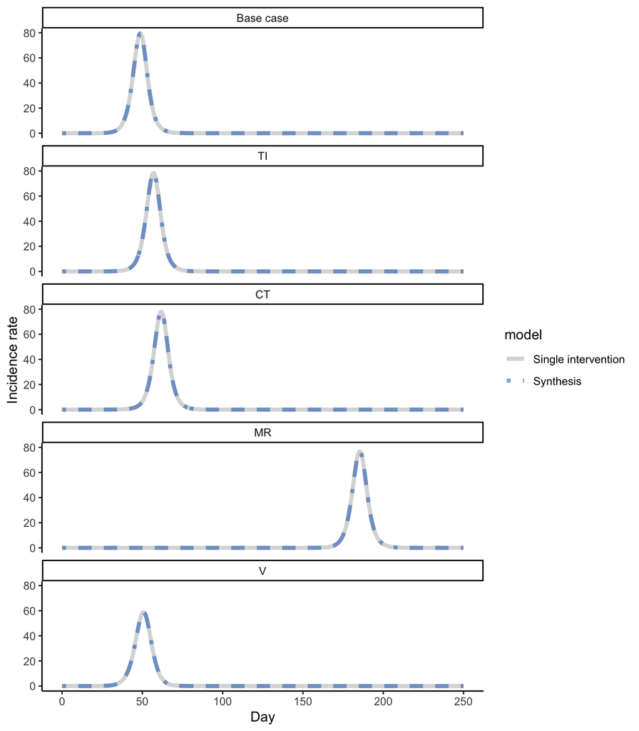

```r
sgl_int <- bind_rows(sim_output_b, sim_output_TI, sim_output_CT, sim_output_MR,
                     sim_output_v)

df <- bind_rows(sim_output_syn, sgl_int) |>
  mutate(itv = factor(itv, levels = c("Base case", "TI", "CT", "MR", "V"),
                      ordered = TRUE))

plot_output_comparison(df)
```

# 3 Simulation

This code simulates the comprehensive intervention.

```r
sim_sth <- sd_simulate(mdl_sth$deSolve_components, start_time = 0,
                       stop_time = 365, timestep = 1/64,
                       integ_method = "euler") |>
  filter(time %in% seq(0, 365, 1/8))
```

The code below performs a scenario analysis. In this analysis, we combine two levels of vaccination willingness and capacity each, resulting in four scenarios.

```r
iota_v_low  <- 0.45

# It is assumed that one individual triggers the outbreak
S1     <- (pop_val - 1) *  iota_v_val # High willingness
S2     <- (pop_val - 1) *  iota_v_low # Low willingness
S_vals <- rep(c(S1, S2), each = 2)

Sh1     <- (pop_val - 1) *  (1 - iota_v_val) # High willingness
Sh2     <- (pop_val - 1) *  (1 - iota_v_low) # Low willingness
Sh_vals <- rep(c(Sh1, Sh2), each = 2)

# Vaccination scenarios
vacn_scn <- data.frame(Qv          = rep(c(Qv_0, 12.26), 2),
                       S           = S_vals,
                       Sh          = Sh_vals,
                       par_rho_v   = rep(c(par_rho_v, 0), 2),
                       par_alpha_v = rep(c(par_alpha_v, 12.26), 2),
                       cap_scn     = rep(c("C1", "C2"), 2),
                       wln_scn     = c("High", "High", "Low", "Low")) |>
  mutate(iter = row_number())
```

```r
vacn_scn |> select(-iter) |>
  mutate(across(where(is.numeric),~round(.x, 2)),
         S  = format(S, big.mark = " "),
         Sh = format(Sh, big.mark = " ")) |>
  gt() |>
    cols_label(
    par_alpha_v      = html("&alpha;<sup>v</sup>"),
    par_rho_v        = html("&rho;<sup>v</sup>"),
    Qv               = html("Q<sub>0</sub><sup>v</sup>"),
    S                = html("S<sub>0</sub>"),
    Sh               = html("S<sub>0</sub><sup>h</sup>"),
    cap_scn          = "Capacity scenario",
    wln_scn          = "Willingness scenario")
```

| Q<sub>0</sub><sup>v</sup> | S<sub>0</sub> | S<sub>0</sub><sup>h</sup> | ρ<sup>v</sup> | α<sup>v</sup> | Capacity scenario | Willingness scenario |
| --- | --- | --- | --- | --- | --- | --- |
| 1.88 | 13 106 560 | 4 368 854 | 0.03 | 12.26 | C1 | High |
| 12.26 | 13 106 560 | 4 368 854 | 0.00 | 12.26 | C2 | High |
| 1.88 | 7 863 936 | 9 611 478 | 0.03 | 12.26 | C1 | Low |
| 12.26 | 7 863 936 | 9 611 478 | 0.00 | 12.26 | C2 | Low |

```r
sim_vacn_scn <- sd_sensitivity_run(mdl_sth$deSolve_components,
                              consts_df = dplyr::select(vacn_scn,
                                                        par_rho_v, par_alpha_v),
                              stocks_df = dplyr::select(vacn_scn, Qv, S, Sh),
                              start_time = 0,
                              stop_time = 365, timestep = 1/64,
                              integ_method = "euler",
                              multicore = TRUE, n_cores = 4) |>
  filter(time %in% seq(0, 365, 1/8)) |>
  left_join(select(vacn_scn, iter, cap_scn, wln_scn))
```

For comparison purposes, we recreate the base-case scenario…

```r
base_mdl <- read_xmile("./models/1A_SEI3R.stmx",
                  const_list = c(bio_params,
                                 par_beta = beta_vals[[2]]))


base_sim <- sd_simulate(base_mdl$deSolve_components,
                       integ_method = "euler", start_time = 0,
                       stop_time = 365, timestep = 1 / 64) |>
  filter(time %in% seq(0, 365, 1/8))
```

and the TTI + MR scenario.

```r
mdl_npi_fp <- "./models/2F_TTI_PLUS_MR.stmx"

mdl_npi <- read_xmile(mdl_npi_fp,
                         const_list  = c(bio_params,
                           par_zeta_0  = zeta_val,
                           par_alpha_d = test_cap_pars$alpha_d,
                           par_alpha_k = ct_cap_pars$alpha_k,
                           par_rho_d   = test_cap_pars$rho_d,
                           par_rho_k   = ct_cap_pars$rho_k,
                           par_tau_m   = par_tau_m,
                           par_xi      = 0.8,
                           par_iota_d  = iota_d_val,
                           par_delta   = delta_val),
                         stock_list = list(
                           Qd = test_cap_pars$Qd,
                           Qk = ct_cap_pars$Qk,
                           Qm = 90))

sim_npi <- sd_simulate(mdl_npi$deSolve_components, start_time = 0,
                       stop_time = 365, timestep = 1/64,
                       integ_method = "euler") |>
  filter(time %in% seq(0, 365, 1/8))
```

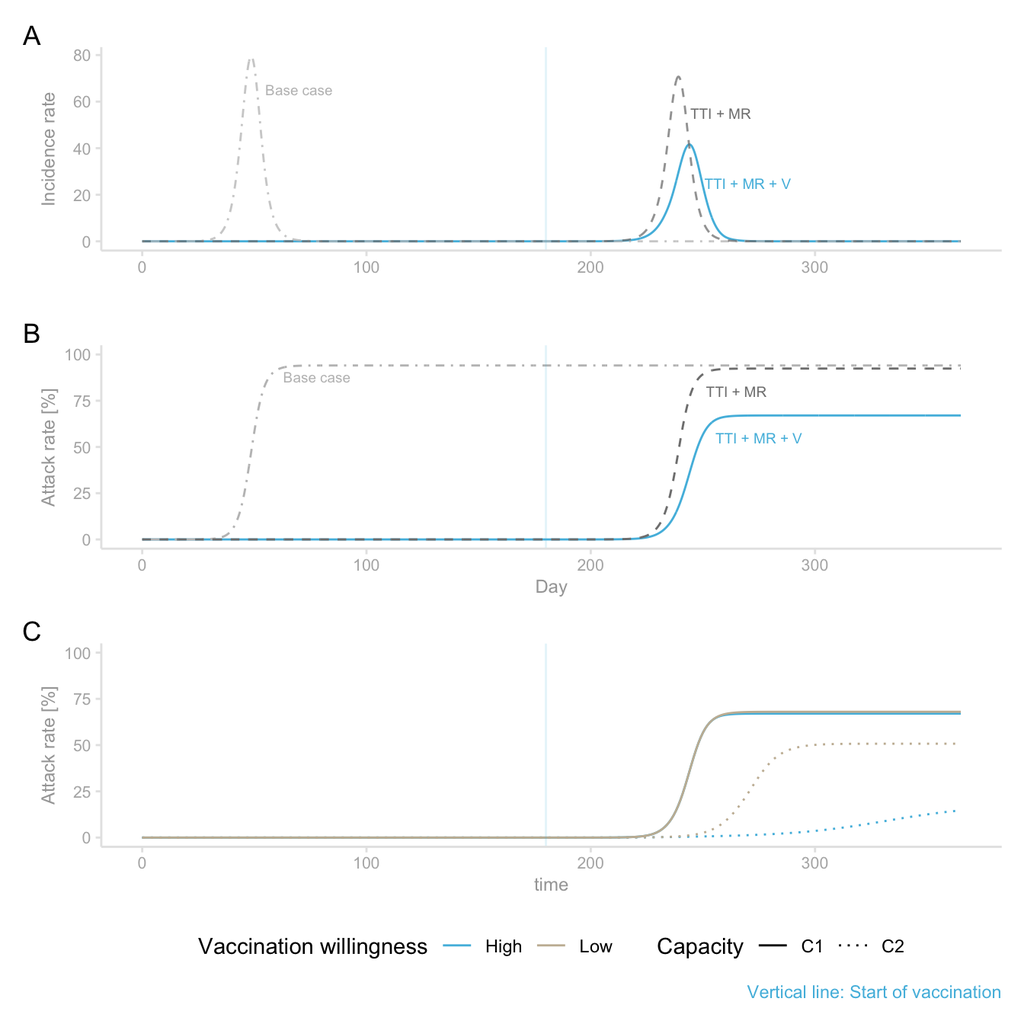

```r
g <- plot_fig_11(sim_sth, base_sim, sim_npi, sim_vacn_scn)

ggsave("./plots/Fig_11_Vaccination_sim.pdf", plot = g,
       height = 7, width = 7, device = cairo_pdf)

g
```

[^1]: https://www.medicalfacts.nl/wp-content/uploads/2021/02/Presentatie_de_heer_Jaap_van_Delden_programmadirecteur_vaccinatie_COVID-19_bij_het_RIVM1.pdf